# Корреспондентный анализ (Correspondence analysis)

## Корреспондентрый анализ и анализ главных компонент

- Сложности при анализе видового состава сообществ при помощи анализа главных компонент
  - Анализ сырых данных
- Корреспондентный анализ
  - Анализ таблиц сопряженности, хи-квадрат
  - Оси в корреспондентном анализе
  - Интерпретация графиков в корреспондентном анализе

### Вы сможете

- Находить проявление “эффекта подковы” в анализе главных компонент
- Проводить корреспондентный анализ таблиц сопряженности
- Объяснить, что именно означает взаиморасположение точек объектов и переменных на графиках результатов корреспондентного анализа
- Интерпретировать графики результатов корреспондентного анализа

## PCA и SVD

## Еще раз суть PCA

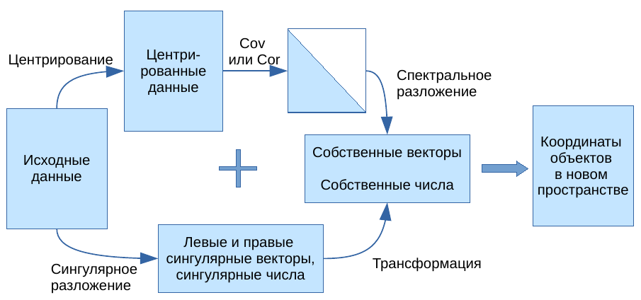

## Данные по протеинам

```r
protein <- read.table(file="data/protein.csv", sep="\t", dec=".", header=TRUE)
protein$region <- factor(protein$region)
rownames(protein) <- protein$country
head(protein)
```

```
##    country      region redmeat whitemeat eggs milk fish cereals
## Al      Al     Balkans    10.1       1.4  0.5  8.9  0.2    42.3
## At      At    W Europe     8.9      14.0  4.3 19.9  2.1    28.0
## Be      Be    W Europe    13.5       9.3  4.1 17.5  4.5    26.6
## Bu      Bu     Balkans     7.8       6.0  1.6  8.3  1.2    56.7
## Cz      Cz    E Europe     9.7      11.4  2.8 12.5  2.0    34.3
## Dk      Dk Scandinavia    10.6      10.8  3.7 25.0  9.9    21.9
##    starch nuts frveg
## Al    0.6  5.5   1.7
## At    3.6  1.3   4.3
## Be    5.7  2.1   4.0
## Bu    1.1  3.7   4.2
## Cz    5.0  1.1   4.0
## Dk    4.8  0.7   2.4
```

Исходная матрица имеет размерность 25, 9

Сколько исходных осей? Сколько объектов?

## PCA данных по протеинам

```r
prot_pca <- rda(protein[, -c(1,2)], scale = FALSE)
```

## Ординация в новых осях

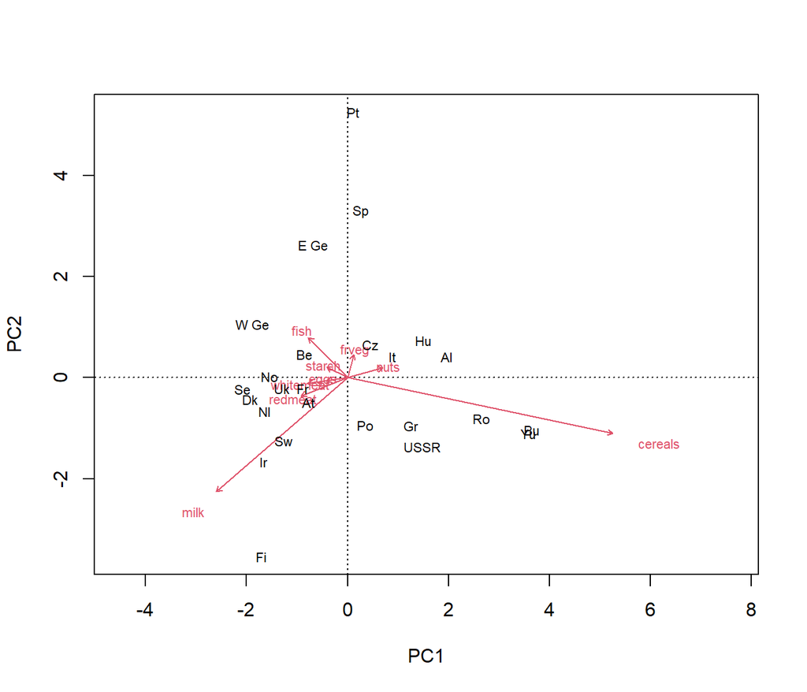

```r
biplot(prot_pca)
```

## Собственные числа

```r
prot_pca$CA$eig
```

```
##     PC1     PC2     PC3     PC4     PC5     PC6     PC7     PC8
## 155.234  30.699  15.643   8.317   3.630   2.429   1.557   0.715
##     PC9
##   0.252
```

```r
summary(prot_pca)
```

```
##
## Call:
## rda(X = protein[, -c(1, 2)], scale = FALSE)
##
## Partitioning of variance:
##               Inertia Proportion
## Total             218          1
## Unconstrained     218          1
##
## Eigenvalues, and their contribution to the variance
##
## Importance of components:
##                           PC1    PC2     PC3    PC4    PC5    PC6
## Eigenvalue            155.234 30.699 15.6435 8.3169 3.6299 2.4288
## Proportion Explained    0.711  0.141  0.0716 0.0381 0.0166 0.0111
## Cumulative Proportion   0.711  0.851  0.9226 0.9607 0.9773 0.9884
##                           PC7     PC8     PC9
## Eigenvalue            1.55680 0.71480 0.25214
## Proportion Explained  0.00713 0.00327 0.00115
## Cumulative Proportion 0.99557 0.99885 1.00000
```

Как определить долю дисперсии, которую описывает каждая из новых осей?

## SVD исходной матрицы

```r
prot_pca <- rda(protein[, -c(1,2)], scale = FALSE)
prot_svd <- svd(scale(protein[, -c(1,2)], center = TRUE, scale = FALSE))

U <- prot_svd$u
D <- prot_svd$d
V <- prot_svd$u
```

## Собственные числа и сингулярные числа

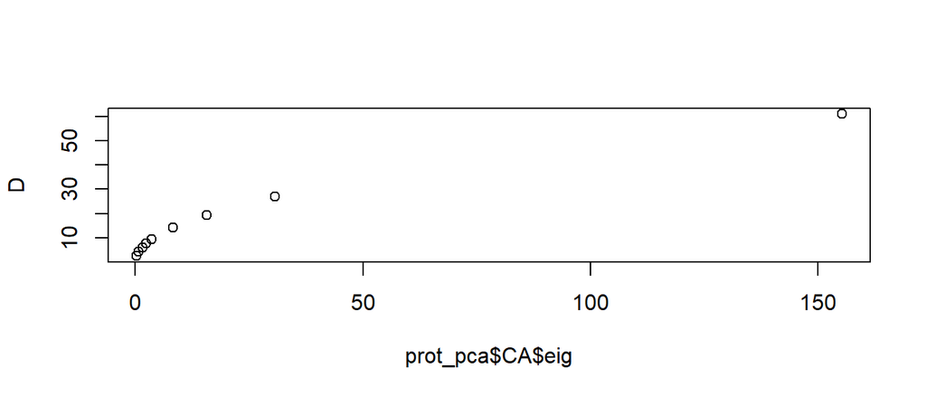

```r
plot(x = prot_pca$CA$eig, y = D)
```

## Собственные векторы (базис новой системы координат) и левая сингулярная матрица **U**

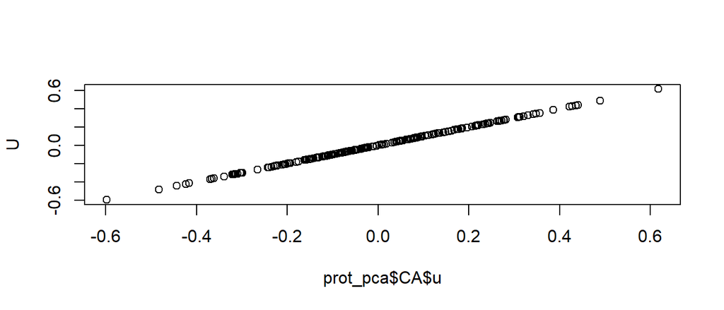

```r
plot(x = prot_pca$CA$u, y = U)
```

Это одно и тоже!

## Координаты объектов в осях главных компонент и правая сингулярная матрица **V**

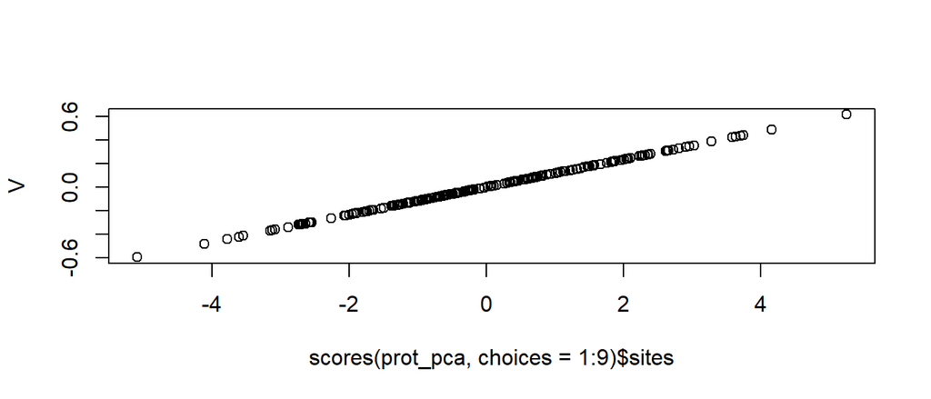

```r
plot(scores(prot_pca, choices = 1:9)$sites, V)
```

Это одно и тоже!

## Итог

Для ординации объектов в новой системе координат, заданной главными компонентами, нет необходимости проводить спектральное разложение:

X -> A -> \(\lambda\), \(U\) -> Новые координаты

Можно короче

X -> SVD -> \(U, D, V\) -> Новые координаты

## Анализ видового состава сообществ.

## Пример: Птицы в лесах Австралии

Обилие 102 видов птиц в 37 сайтах в юго-восточной Австралии (Mac Nally, 1989; данные из Quinn, Keough, 2002). Можно ли описать отношения между сайтами небольшим числом главных компонент?

```r
library(readxl)
birds <- read_excel(path = "data/macnally.xlsx")

# имена переводим в нижний регистр
colnames(birds) <- tolower(colnames(birds))
```

## Задание:

- Проведите анализ главных компонент и получите вот такую иллюстрацию

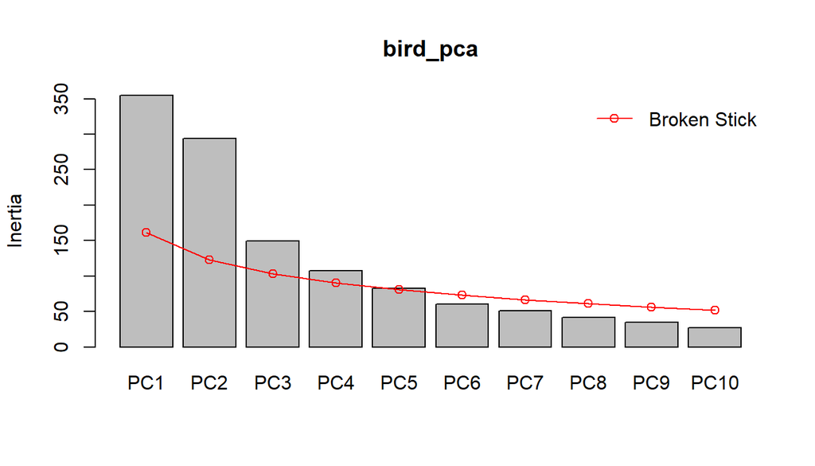

Сколько главных компонент имеет смысл рассматривать?

## Задание:

- Оцените информативность компонент и получите вот такую таблицу

```
## Importance of components:
##                           PC1     PC2     PC3      PC4     PC5
## Eigenvalue            354.809 293.938 149.833 107.2730 82.7350
## Proportion Explained    0.254   0.211   0.107   0.0769  0.0593
## Cumulative Proportion   0.254   0.465   0.573   0.6496  0.7089
##                           PC6     PC7     PC8     PC9    PC10    PC11
## Eigenvalue            60.3985 51.0587 42.0381 34.7701 27.1625 25.3131
## Proportion Explained   0.0433  0.0366  0.0301  0.0249  0.0195  0.0182
## Cumulative Proportion  0.7522  0.7888  0.8190  0.8439  0.8634  0.8816
##                          PC12    PC13    PC14   PC15     PC16
## Eigenvalue            22.2225 18.6550 16.3308 15.346 12.29099
## Proportion Explained   0.0159  0.0134  0.0117  0.011  0.00881
## Cumulative Proportion  0.8975  0.9109  0.9226  0.934  0.94240
##                           PC17    PC18    PC19    PC20    PC21
## Eigenvalue            10.79984 9.07912 8.49626 7.45981 6.02566
## Proportion Explained   0.00774 0.00651 0.00609 0.00535 0.00432
## Cumulative Proportion  0.95015 0.95666 0.96275 0.96810 0.97242
##                          PC22    PC23    PC24    PC25    PC26    PC27
## Eigenvalue            5.93175 5.12836 4.41659 4.00184 3.66664 2.95938
## Proportion Explained  0.00425 0.00368 0.00317 0.00287 0.00263 0.00212
## Cumulative Proportion 0.97667 0.98035 0.98352 0.98639 0.98902 0.99114
##                          PC28    PC29    PC30    PC31    PC32
## Eigenvalue            2.56467 2.26089 1.98446 1.73851 1.50507
## Proportion Explained  0.00184 0.00162 0.00142 0.00125 0.00108
## Cumulative Proportion 0.99298 0.99460 0.99602 0.99727 0.99835
##                           PC33     PC34     PC35     PC36
## Eigenvalue            0.837891 0.733712 0.453209 0.276242
## Proportion Explained  0.000601 0.000526 0.000325 0.000198
## Cumulative Proportion 0.998951 0.999477 0.999802 1.000000
```

## Задание:

- Постройте ординацию сайтов и видов в осях 1-й и 2-й главных компонент и получите вот такую иллюстрацию

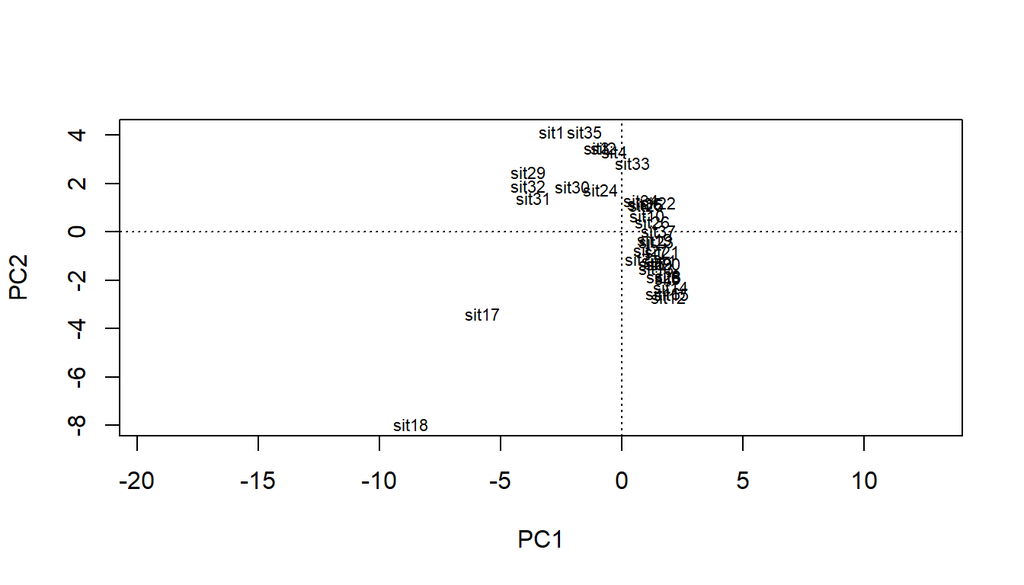

## Решение: PCA и анализ информативности

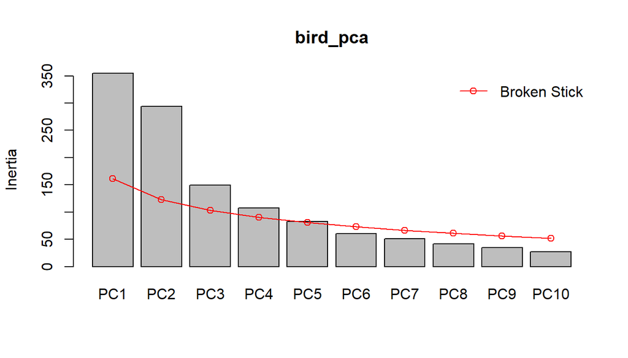

```r
library(vegan)
bird_pca <- rda(birds[ , -c(1, 2)], scale = FALSE)
# summary(bird_pca)
screeplot(bird_pca,  bstick = TRUE) # график собственных чисел
```

- Первые две компоненты объясняют умеренное количество изменчивости

## Решение: Факторные нагрузки

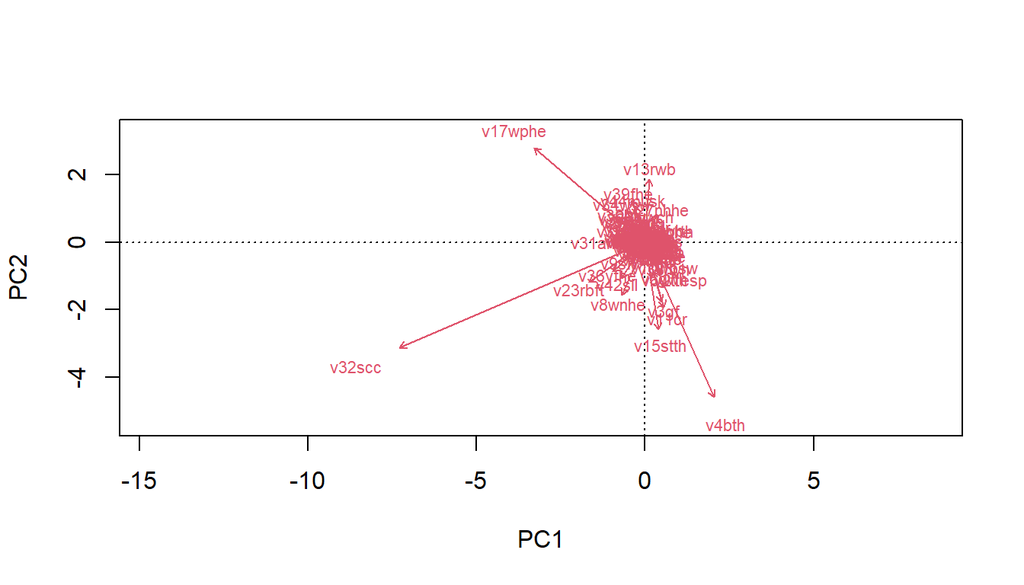

```r
biplot(bird_pca, display = "species", scaling = "symmetric", type = "t")
```

- У многих переменных факторные нагрузки велики сразу на две оси. Это может быть неудобно.

## Решение: Ординация сайтов

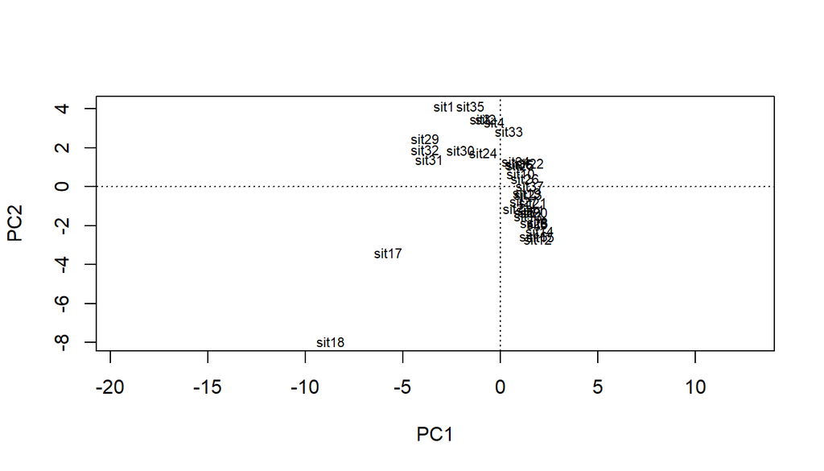

```r
plot(bird_pca, display = "sites")
```

Обратите внимание, ординация сайтов в виде подковы!

- Так происходит от того, что завышены корреляции между переменными из-за большого числа нулей

## Эффект подковы в симулированном примере

Построим искусственный градиент

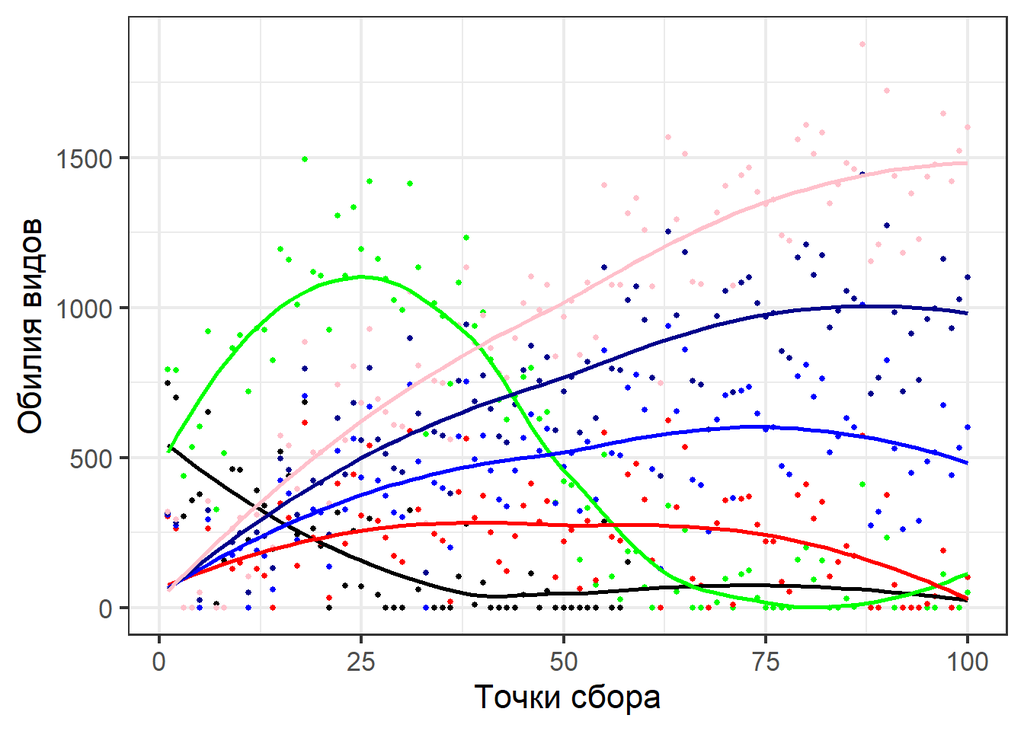

## Эффект подковы в симулированном примере

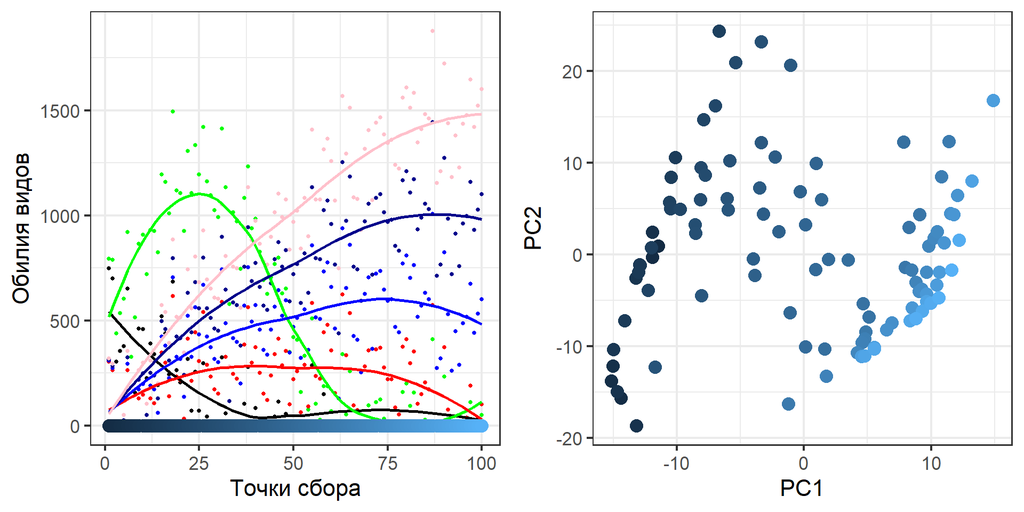

## Для успешного применения анализа главных компонент нужно:

- Линейные связи между переменными (т.к. матрица корреляций или ковариаций, подразумевает линейность связей)
- Исключить наблюдения, в которых есть пропущенные значения
- Если много нулей - трансформация данных
- Если очень много нулей - удалить такие переменные из анализа (иногда это большая редукция!)
- Если есть один или несколько пространственных градиентов, то часто лучше отказаться от PCA и использовать другие типы анализов.

## Пример: клещи

Клещи-орибатиды на сплавине одного из канадских озер

На площадке 10 х 2.6м взяли стратифицированную случайную выборку (70 проб) на 7 типах субстратов. (Borcard & Legendre 1994).

Oribatid mite with a visiting friendly springtail by [Andy Murray on Flickr](https://flic.kr/p/bqAFBs)

Tourbière/Peat bog* by [peupleloup on Flickr](https://flic.kr/p/51F8Ks)

- - peat bog - зыбун, сплавина (плавина)

## Структура данных

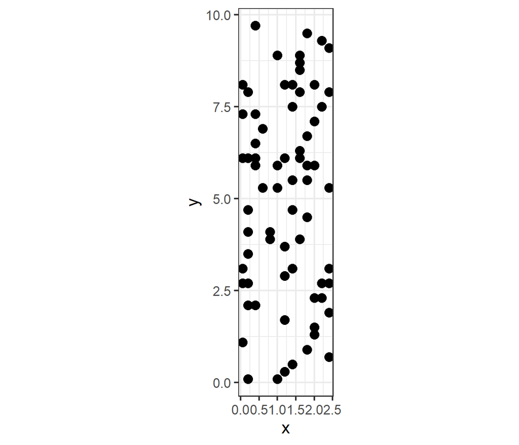

```r
library(vegan)
data(mite)
head(mite[, 1:5])
```

```
##   Brachy PHTH HPAV RARD SSTR
## 1     17    5    5    3    2
## 2      2    7   16    0    6
## 3      4    3    1    1    2
## 4     23    7   10    2    2
## 5      5    8   13    9    0
## 6     19    7    5    9    3
```

## Задание:

- Проведите анализ главных компонент, Нарисуйте биплот, сохраняющий эвклидовы расстояния между объектами. Получите вот такие иллюстрации

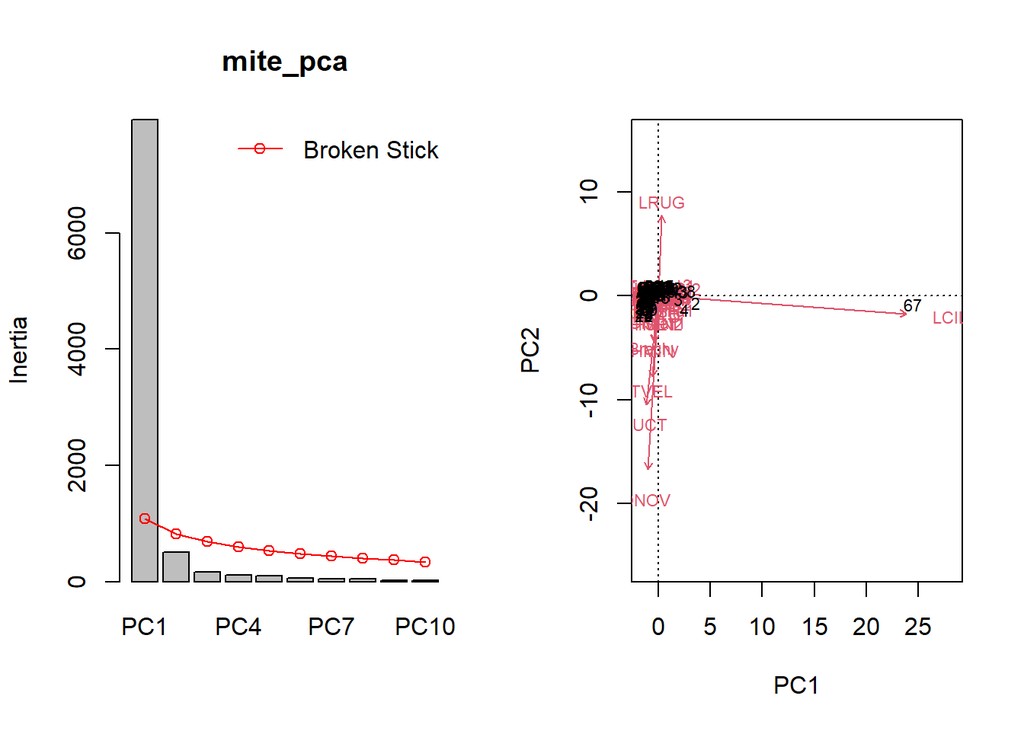

## Решение

```r
mite_pca <- rda(mite)

screeplot(mite_pca, bstick = T)

biplot(mite_pca,  scaling = "sites", type = "t")
```

## PCA vs MDS

```r
mite_mds <- metaMDS(mite, trace = F)
```

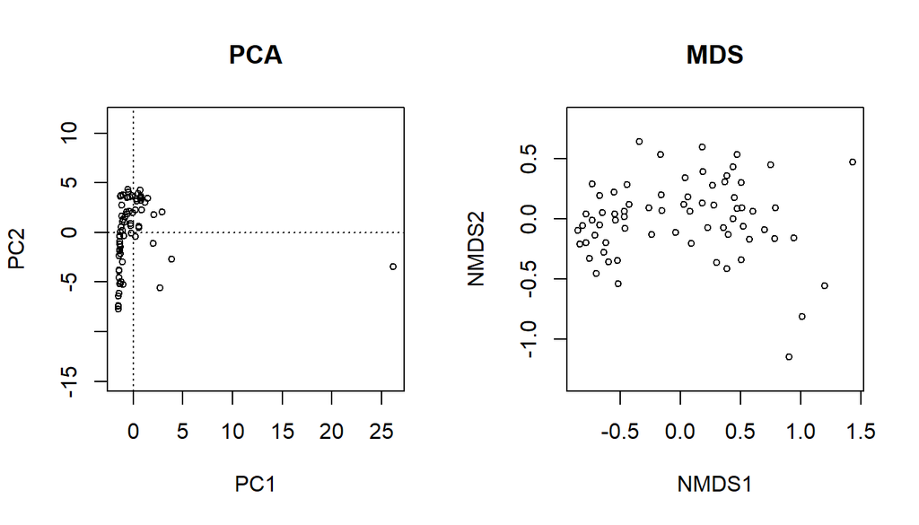

Проблемы PCA:

- Есть отскакивающее значение
- Вырисовывается “подкова”

## Может лучше MDS?

### Pro

- MDS может работать с любыми данными
- MDS лучше отражает градиенты

### Contra

- MDS не дает в явном виде информации о **связи признаков**
- **Оси MDS безлики** их информативность не поддается оценке
- Оси MDS трудно использовать как **комплексные признаки**
- Существует третий путь - **Корреспондентный анализ**

## Корреспондентный анализ (Correspondence analysis)

## Корреспондентный анализ “в темную”

```r
mite_ca <- cca(mite)
head(summary(mite_ca))
```

```
## $species
##              CA1     CA2     CA3      CA4      CA5      CA6
## Brachy   -0.4850 -0.0269  0.0710 -0.52661  0.22505 -0.28329
## PHTH     -0.7073  0.6263 -0.0814 -0.22192  0.05648 -0.22724
## HPAV      0.0383 -0.4563  0.0134 -0.50099 -0.10960 -0.15183
## RARD     -1.0186  0.4771 -0.0138 -0.32885  0.03265  0.61861
## SSTR     -0.3119  0.9674 -0.2970 -0.01303 -0.03339 -0.47297
## Protopl  -0.9513  0.5156 -0.0971 -0.44041  0.15263  0.28345
## MEGR     -0.2188  0.4729  0.1663  0.14439  0.57595 -0.21845
## MPRO     -0.3034  0.0981 -0.3947  0.20641  0.30147  0.17477
## TVIE      0.6114 -0.7114  0.6117 -0.60673 -0.50997 -0.01441
## HMIN     -0.8110 -0.2656 -0.1465  1.13783 -0.42259 -0.13161
## HMIN2    -0.8180  0.5646 -0.0844 -0.09259  0.01045 -0.69255
## NPRA     -0.3663 -0.1454  0.0756 -0.23153 -0.08008 -0.00582
## TVEL     -0.7870  0.3969 -0.0953 -0.37256  0.22629  0.34398
## ONOV     -0.5978  0.0175  0.1150  0.30862 -0.16396 -0.08239
## SUCT     -0.5770 -0.1476 -0.0120  0.01775 -0.04220  0.41879
## LCIL      0.9994  0.3817 -0.2153  0.07271 -0.02351  0.04403
## Oribatl1 -0.7481  0.5941 -0.0906 -0.05685 -0.04349 -0.53256
## Ceratoz1 -0.0594 -0.4656  0.1181 -0.20864  0.09965  0.19408
## PWIL     -0.4822  0.2792  0.0170 -0.21516  0.16371 -0.42327
## Galumna1 -0.8164  0.4810 -0.0959 -0.00843 -0.05399 -0.18098
## Stgncrs2 -0.5237  0.8267 -0.1806 -0.12478  0.02821 -0.43123
## HRUF      0.0471  0.1394  0.0349 -0.06753  0.32406 -0.84062
## Trhypch1  0.8409  0.2724  2.6364  0.49232  0.72094  0.05728
## PPEL     -0.5839  0.7092  0.2541 -0.29152 -0.15886 -1.23043
## NCOR      0.3430 -0.7390  0.1429 -0.03204  0.01168 -0.07574
## SLAT     -0.8343  0.6119 -0.0879 -0.09269 -0.00577 -1.70786
## FSET     -0.8457  0.4986 -0.0804  0.06590 -0.10317 -0.15697
## Lepidzts -0.8524  0.5729 -0.0971 -0.87252  0.34591 -0.01275
## Eupelops -0.5088 -0.2427 -0.1545  0.24848  0.14614  0.06192
## Miniglmn -1.0137  0.4113 -0.0282  0.23937 -0.22844 -1.67223
## LRUG      0.5213 -1.1042 -0.2530  0.07732  0.35212 -0.14707
## PLAG2     0.1947 -1.1241 -0.0905  0.50035  0.19181  0.13220
## Ceratoz3  0.4774 -1.1207  0.0314 -0.39594 -0.23274  0.01048
## Oppiminu -0.0571 -0.9124 -0.1694  0.38754  0.29769  0.25528
## Trimalc2  0.9373 -0.4007  1.1614 -0.81243 -1.65806 -0.00537
##
## $sites
##        CA1     CA2      CA3     CA4      CA5      CA6
```

[output cut: 92 more lines]

```
## Eigenvalue            0.0265 0.0222 0.0198 0.01660 0.01587 0.01478
## Proportion Explained  0.0156 0.0131 0.0117 0.00979 0.00936 0.00871
## Cumulative Proportion 0.8991 0.9123 0.9239 0.93371 0.94306 0.95177
##                          CA20    CA21    CA22    CA23    CA24    CA25
## Eigenvalue            0.01252 0.01038 0.00926 0.00784 0.00677 0.00661
## Proportion Explained  0.00738 0.00612 0.00546 0.00462 0.00399 0.00390
## Cumulative Proportion 0.95915 0.96527 0.97073 0.97536 0.97935 0.98324
##                          CA26    CA27    CA28    CA29    CA30    CA31
## Eigenvalue            0.00576 0.00524 0.00451 0.00341 0.00283 0.00249
## Proportion Explained  0.00339 0.00309 0.00266 0.00201 0.00167 0.00147
## Cumulative Proportion 0.98664 0.98972 0.99238 0.99439 0.99606 0.99752
##                          CA32     CA33     CA34
## Eigenvalue            0.00187 0.001296 0.001036
## Proportion Explained  0.00110 0.000764 0.000611
## Cumulative Proportion 0.99863 0.999389 1.000000
```

## Ординация проб

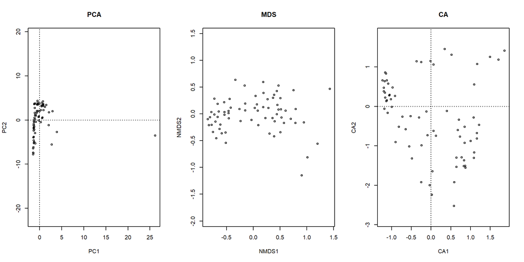

## Ординация проб

```r
op <- par(mfrow = c(1, 3))
plot(mite_pca, display = "sites", main = "PCA", type = "p")
plot(mite_mds, display = "sites",  main = "MDS")
plot(mite_ca, display = "sites", type = "p", main = "CA")
par(op)
```

## Cвязь проб и видов

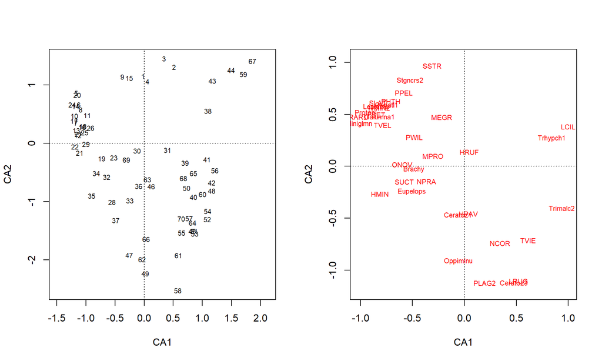

## Cвязь проб и видов

```r
op <- par(mfrow = c(1, 2))

plot(mite_ca, display = "sites")
plot(mite_ca, display = "species")

par(op)
```

## Cвязь проб и видов

Можно на одном графике

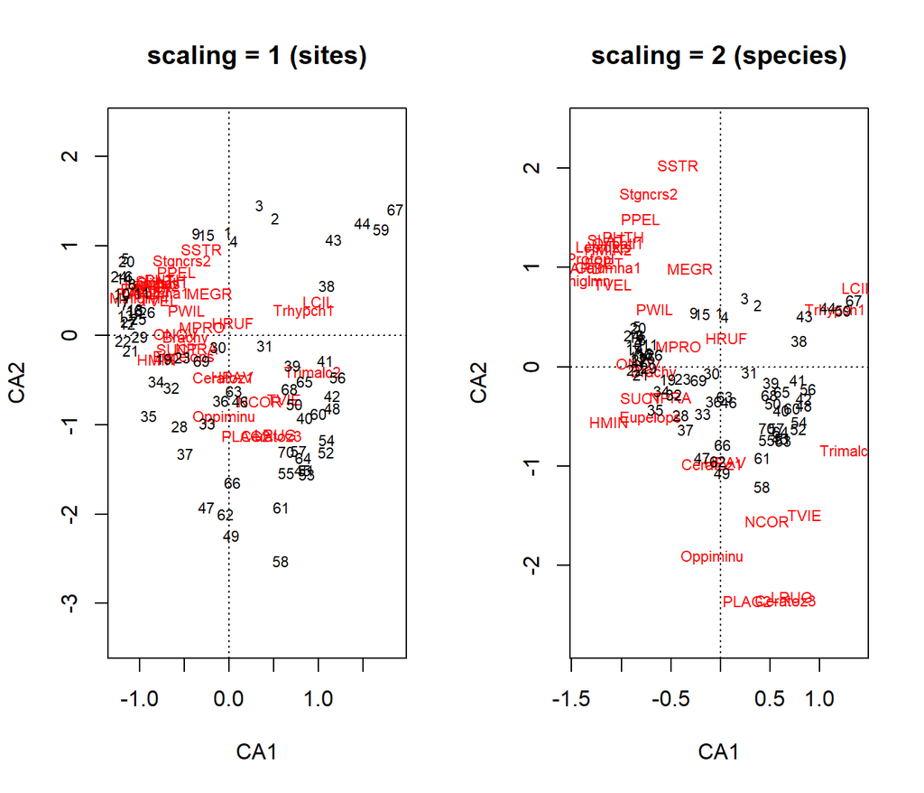